# Prosper Loan Data Exploration

## Introduction

This project is on a data set from Prosper, which is America’s first marketplace lending platform, with over $7 billion in funded loans. This data set contains 113,937 loans with 81 variables on each loan, including loan amount, borrower rate (or interest rate), current loan status, borrower income, borrower employment status, borrower credit history, and the latest payment information. The main purpose of this project is to summarize the characteristics of variables that can affect the loan status and to get some ideas about the relationships among multiple variables using summary statistics and data visualizations.

## Preliminary Wrangling

```python
# import all packages and set plots to be embedded inline
import numpy as np
import pandas as pd
import matplotlib.pyplot as plt
import seaborn as sb

%matplotlib inline
```

```python
Loan = pd.read_csv('C:\\Users\\sodiq\\Downloads\\prosperLoanData.csv')
```

```python
# high-level overview of data shape and composition
Loan.shape
```

```
(113937, 81)
```

```python
Loan.info()
```

```
<class 'pandas.core.frame.DataFrame'>
RangeIndex: 113937 entries, 0 to 113936
Data columns (total 81 columns):
 #   Column                               Non-Null Count   Dtype
---  ------                               --------------   -----
 0   ListingKey                           113937 non-null  object
 1   ListingNumber                        113937 non-null  int64
 2   ListingCreationDate                  113937 non-null  object
 3   CreditGrade                          28953 non-null   object
 4   Term                                 113937 non-null  int64
 5   LoanStatus                           113937 non-null  object
 6   ClosedDate                           55089 non-null   object
 7   BorrowerAPR                          113912 non-null  float64
 8   BorrowerRate                         113937 non-null  float64
 9   LenderYield                          113937 non-null  float64
```

[output cut: 73 more lines]

```python
Loan.head()
```

|  | ListingKey | ListingNumber | ListingCreationDate | CreditGrade | Term | LoanStatus | ClosedDate | BorrowerAPR | BorrowerRate | LenderYield | ... | LP_ServiceFees | LP_CollectionFees | LP_GrossPrincipalLoss | LP_NetPrincipalLoss | LP_NonPrincipalRecoverypayments | PercentFunded | Recommendations | InvestmentFromFriendsCount | InvestmentFromFriendsAmount | Investors |
| --- | --- | --- | --- | --- | --- | --- | --- | --- | --- | --- | --- | --- | --- | --- | --- | --- | --- | --- | --- | --- | --- |
| 0 | 1021339766868145413AB3B | 193129 | 2007-08-26 19:09:29.263000000 | C | 36 | Completed | 2009-08-14 00:00:00 | 0.16516 | 0.1580 | 0.1380 | ... | -133.18 | 0.0 | 0.0 | 0.0 | 0.0 | 1.0 | 0 | 0 | 0.0 | 258 |
| 1 | 10273602499503308B223C1 | 1209647 | 2014-02-27 08:28:07.900000000 | NaN | 36 | Current | NaN | 0.12016 | 0.0920 | 0.0820 | ... | 0.00 | 0.0 | 0.0 | 0.0 | 0.0 | 1.0 | 0 | 0 | 0.0 | 1 |
| 2 | 0EE9337825851032864889A | 81716 | 2007-01-05 15:00:47.090000000 | HR | 36 | Completed | 2009-12-17 00:00:00 | 0.28269 | 0.2750 | 0.2400 | ... | -24.20 | 0.0 | 0.0 | 0.0 | 0.0 | 1.0 | 0 | 0 | 0.0 | 41 |
| 3 | 0EF5356002482715299901A | 658116 | 2012-10-22 11:02:35.010000000 | NaN | 36 | Current | NaN | 0.12528 | 0.0974 | 0.0874 | ... | -108.01 | 0.0 | 0.0 | 0.0 | 0.0 | 1.0 | 0 | 0 | 0.0 | 158 |
| 4 | 0F023589499656230C5E3E2 | 909464 | 2013-09-14 18:38:39.097000000 | NaN | 36 | Current | NaN | 0.24614 | 0.2085 | 0.1985 | ... | -60.27 | 0.0 | 0.0 | 0.0 | 0.0 | 1.0 | 0 | 0 | 0.0 | 20 |

5 rows × 81 columns

```python
Loan.describe()
```

|  | ListingNumber | Term | BorrowerAPR | BorrowerRate | LenderYield | EstimatedEffectiveYield | EstimatedLoss | EstimatedReturn | ProsperRating (numeric) | ProsperScore | ... | LP_ServiceFees | LP_CollectionFees | LP_GrossPrincipalLoss | LP_NetPrincipalLoss | LP_NonPrincipalRecoverypayments | PercentFunded | Recommendations | InvestmentFromFriendsCount | InvestmentFromFriendsAmount | Investors |
| --- | --- | --- | --- | --- | --- | --- | --- | --- | --- | --- | --- | --- | --- | --- | --- | --- | --- | --- | --- | --- | --- |
| count | 1.139370e+05 | 113937.000000 | 113912.000000 | 113937.000000 | 113937.000000 | 84853.000000 | 84853.000000 | 84853.000000 | 84853.000000 | 84853.000000 | ... | 113937.000000 | 113937.000000 | 113937.000000 | 113937.000000 | 113937.000000 | 113937.000000 | 113937.000000 | 113937.000000 | 113937.000000 | 113937.000000 |
| mean | 6.278857e+05 | 40.830248 | 0.218828 | 0.192764 | 0.182701 | 0.168661 | 0.080306 | 0.096068 | 4.072243 | 5.950067 | ... | -54.725641 | -14.242698 | 700.446342 | 681.420499 | 25.142686 | 0.998584 | 0.048027 | 0.023460 | 16.550751 | 80.475228 |
| std | 3.280762e+05 | 10.436212 | 0.080364 | 0.074818 | 0.074516 | 0.068467 | 0.046764 | 0.030403 | 1.673227 | 2.376501 | ... | 60.675425 | 109.232758 | 2388.513831 | 2357.167068 | 275.657937 | 0.017919 | 0.332353 | 0.232412 | 294.545422 | 103.239020 |
| min | 4.000000e+00 | 12.000000 | 0.006530 | 0.000000 | -0.010000 | -0.182700 | 0.004900 | -0.182700 | 1.000000 | 1.000000 | ... | -664.870000 | -9274.750000 | -94.200000 | -954.550000 | 0.000000 | 0.700000 | 0.000000 | 0.000000 | 0.000000 | 1.000000 |
| 25% | 4.009190e+05 | 36.000000 | 0.156290 | 0.134000 | 0.124200 | 0.115670 | 0.042400 | 0.074080 | 3.000000 | 4.000000 | ... | -73.180000 | 0.000000 | 0.000000 | 0.000000 | 0.000000 | 1.000000 | 0.000000 | 0.000000 | 0.000000 | 2.000000 |
| 50% | 6.005540e+05 | 36.000000 | 0.209760 | 0.184000 | 0.173000 | 0.161500 | 0.072400 | 0.091700 | 4.000000 | 6.000000 | ... | -34.440000 | 0.000000 | 0.000000 | 0.000000 | 0.000000 | 1.000000 | 0.000000 | 0.000000 | 0.000000 | 44.000000 |
| 75% | 8.926340e+05 | 36.000000 | 0.283810 | 0.250000 | 0.240000 | 0.224300 | 0.112000 | 0.116600 | 5.000000 | 8.000000 | ... | -13.920000 | 0.000000 | 0.000000 | 0.000000 | 0.000000 | 1.000000 | 0.000000 | 0.000000 | 0.000000 | 115.000000 |
| max | 1.255725e+06 | 60.000000 | 0.512290 | 0.497500 | 0.492500 | 0.319900 | 0.366000 | 0.283700 | 7.000000 | 11.000000 | ... | 32.060000 | 0.000000 | 25000.000000 | 25000.000000 | 21117.900000 | 1.012500 | 39.000000 | 33.000000 | 25000.000000 | 1189.000000 |

8 rows × 61 columns

### What is the structure of your dataset?

This data set contains 113,937 loans with 81 variables

### What is/are the main feature(s) of interest in your dataset?

The main purpose of this project is to summarize the characteristics of variables that can affect the loan status and to get some ideas about the relationships among multiple variables using summary statistics and data visualizations.

### What features in the dataset do you think will help support your investigation into your feature(s) of interest?

I expect that there will be positive realtionship between the interest rate and lenderyield

## 1. The number of listing in each state

```python
def loan(xl,yl,title):
    plt.title(title)
    plt.xlabel(xl)
    plt.ylabel(yl)
```

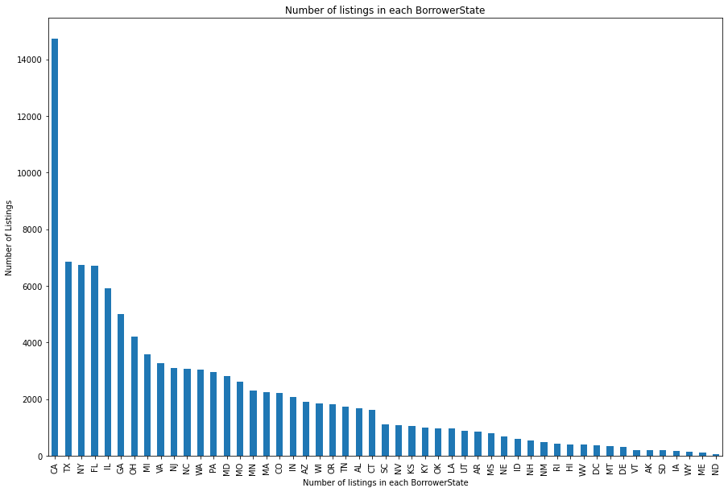

```python
Loan.BorrowerState.value_counts().plot(kind='bar', figsize=(15,10))
loan('Number of listings in each BorrowerState','Number of Listings','Number of listings in each BorrowerState')
```

## Insights

The data says the highest listing counts in CA, TX, NY, FL and IL, which tracks with the rankings of top US states by population and the least in WY, ME, ND. In other words, the Prosper listings are distributed similarly to the population of the US.

## 2. Income rate distribution of Listing

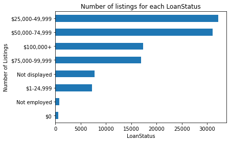

```python
Loan['IncomeRange'].value_counts().sort_values().plot(kind='barh');
loan('LoanStatus','Number of Listings','Number of listings for each LoanStatus')
```

## 3. Analyzing the number of income verified, checking if lenders are currently in a group and confirming if they have collateral

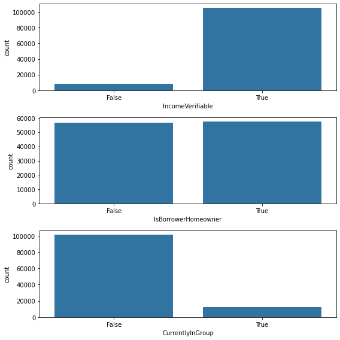

```python
# let's plot all three together to get an idea of each boolean variable's distribution.

fig, ax = plt.subplots(nrows=3, figsize = [8,8])

default_color = sb.color_palette()[0]
sb.countplot(data = Loan, x = 'IncomeVerifiable', color = default_color, ax = ax[0])
sb.countplot(data = Loan, x = 'IsBorrowerHomeowner', color = default_color, ax = ax[1])
sb.countplot(data = Loan, x = 'CurrentlyInGroup', color = default_color, ax = ax[2])

#optimize distance between subplots
plt.tight_layout()
plt.show()
```

## Insights

It can be deduced that most income was verified beofre issuance of loan. It can be seen that most people were not currently in a group as at the time of getting a loan and there is no huge difference between those that have collateral and those that don't have.

## 4. Analsis on the number of listings under each LoanStatus available, credit grade and employment status

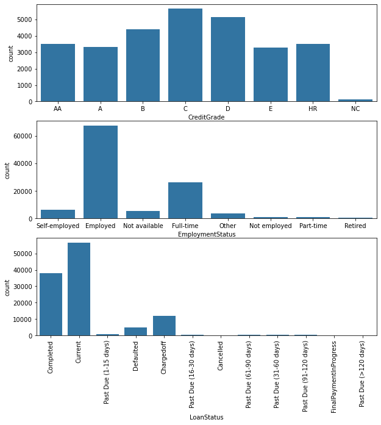

```python
# let's plot all three together to get an idea of each ordinal variable's distribution.

fig, ax = plt.subplots(nrows=3, figsize = [10,10])
order_C = ['AA','A','B','C','D','E','HR','NC']
default_color = sb.color_palette()[0]
sb.countplot(data = Loan, x = 'CreditGrade', color = default_color,order = order_C, ax = ax[0])

sb.countplot(data = Loan, x = 'EmploymentStatus', color = default_color, ax = ax[1])
plt.xticks(rotation=90)

sb.countplot(data = Loan, x = 'LoanStatus', color = default_color, ax = ax[2])
plt.xticks(rotation=90)


plt.show()
```

## Insights

The number of listings in each LoanStatus type are analyzed and the plot shows that Current status has got the highest number of listings followed by Completed and Chargedoff. Other statuses include dues for various intervals and cancelled whose frequency is too less. It can also be seen that in the employment status, employed has the highest frequency followed by fulltime and self-employed. The highest credit grade is C while the lowest credit grade is NC.

## Bivariate Exploration

### 1. Checking the correlation between some selected variables using the matrix and bar methods

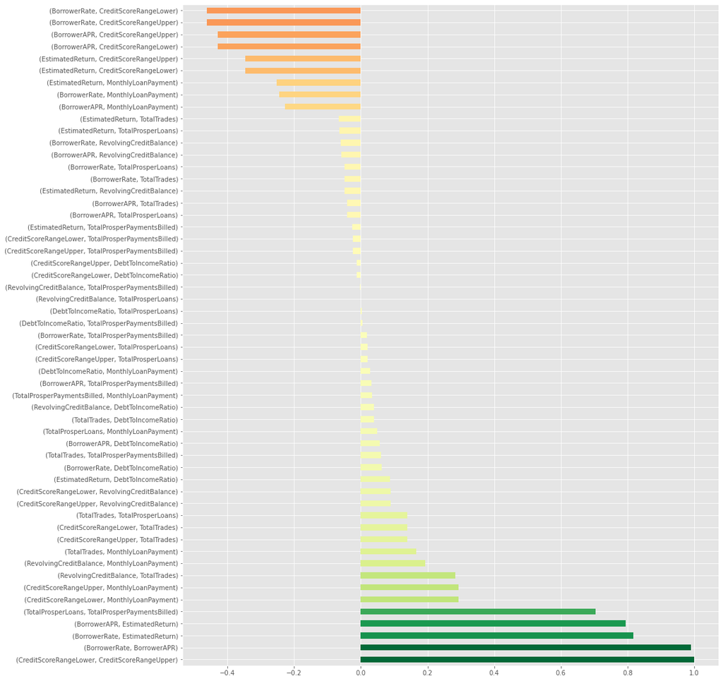

```python
plt.style.use('ggplot')
from matplotlib.colors import TwoSlopeNorm
columns=['BorrowerRate','BorrowerAPR','EstimatedReturn','CreditScoreRangeLower','CreditScoreRangeUpper','RevolvingCreditBalance','TotalTrades',
        'DebtToIncomeRatio','TotalProsperLoans','TotalProsperPaymentsBilled','MonthlyLoanPayment']
def get_redundant_pairs(Loan):
    pairs_to_drop = set()
    cols = Loan.columns
    for i in range(0, Loan.shape[1]):
        for j in range(0, i+1):
            pairs_to_drop.add((cols[i], cols[j]))
    return pairs_to_drop

def get_correlations(Loan):
    au_corr = Loan.corr().unstack()
    labels_to_drop = get_redundant_pairs(Loan)
    au_corr = au_corr.drop(labels=labels_to_drop).sort_values(ascending=False)
    return au_corr

corrplot = get_correlations(Loan[columns])

fig,ax = plt.subplots(figsize=(15,19))

norm = TwoSlopeNorm(vmin=-1,vcenter=0, vmax=1)
colors = [plt.cm.RdYlGn(norm(c)) for c in corrplot.values]

corrplot.plot.barh(color=colors)
```

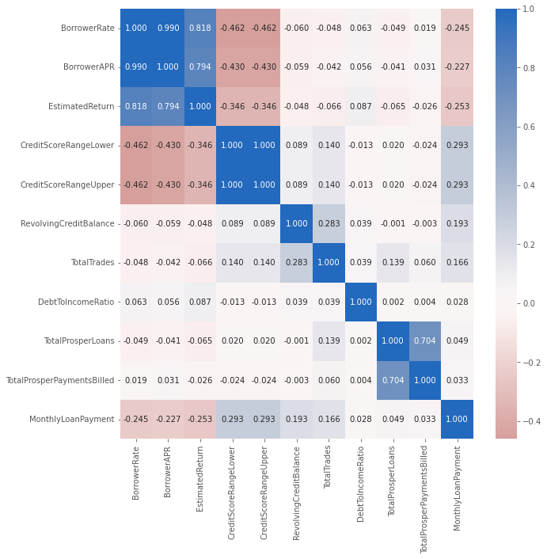

```python
numeric_vars = ['BorrowerRate','BorrowerAPR','EstimatedReturn','CreditScoreRangeLower','CreditScoreRangeUpper','RevolvingCreditBalance','TotalTrades',
        'DebtToIncomeRatio','TotalProsperLoans','TotalProsperPaymentsBilled','MonthlyLoanPayment']
categoric_vars = ['CreditGrade', 'EmploymentStatus']

# correlation plot
plt.figure(figsize = [10, 10])
sb.heatmap(Loan[numeric_vars].corr(), annot = True, fmt = '.3f',
           cmap = 'vlag_r', center = 0)
plt.show()
```

Interestingly, it appears that there are some strong positive relationships between some veraible like borrowerAPR and borrowerrate, estimated return and borrowerrate, Total prosperloan and total prosperpaymnet bills and the likes. They are aslo negative relationships in some variables as well like Borrowerrate and totaltrades, BorrowerApr and totalprosper loans,etc.

## 2 Borrowerrate VS Lenderyield

### Is there any relationship between Borrower rate and Lender yield?

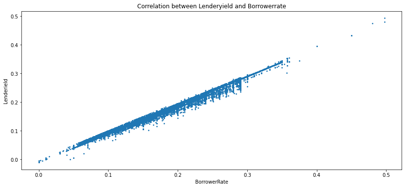

```python
# scatter plot of Borrowerrate vs. Lenderyield

plt.figure(figsize = [14, 6])
plt.scatter(data = Loan, y = 'LenderYield', x = 'BorrowerRate', s = 3)
loan('BorrowerRate','Lenderield','Correlation between Lenderyield and Borrowerrate')
plt.show()
```

It can be deduced from the above bivatriate analysis that lender iend and borrowerrate(interest rate) has a strong rlationship I.e the higher the interest rate, the higher the lenderyield and I belive this will also go the same pattern with the estimated return yield as well.

## 3. BorrowerRate pattern over years

### What year has the highest borrower rate(interest rate)?

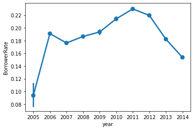

```python
# Get the year from the creation date and create a column for it

Loan['year'] = Loan.ListingCreationDate.str.split('-').str[0]

# plots the pointplot for year vs BorrowerRate
order_date = ['2005','2006','2007','2008','2009','2010','2011','2012','2013','2014']

sb.pointplot(data=Loan, x='year', y='BorrowerRate', order=order_date);
```

### Insights

Point plot is used to analyze this and it suites the analysis because this graph shows the nature of the variable from one xfactor to another. For this scenario, it shows that rate of interest increased from 2005-2006 and then fell off from 2006-2007 and then it constantly picked up for few years, reached its peak in 2011 which then started decreasing constantly.

## Income range vs ProsperPrincipalBorrowed

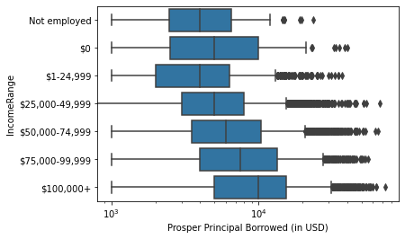

```python
Loan.IncomeRange.value_counts()

# orders the x axis
order = ['Not employed', '$0', '$1-24,999', '$25,000-49,999', '$50,000-74,999', '$75,000-99,999', '$100,000+']
color = sb.color_palette()[0]
# plots the boxplot
sb.boxplot(data=Loan, y='IncomeRange', x='ProsperPrincipalBorrowed', color=color,order=order,orient='h');

# scale the y axis with log to analyze more accurately
plt.xscale('log')

plt.xlabel('Prosper Principal Borrowed (in USD)');
```

## Insights

In this scenario, a boxplot is used to depict the results. The insights from the boxplot are the medians are in increasing order i.e., the more the income range the more the principal amount borrowed from the Prosper except for the not employed or 0 dollar salaried.

## Multivariate Exploration

I will analyze how the BorrowerRate changed over years for Homeowners vs Non-Homeowners

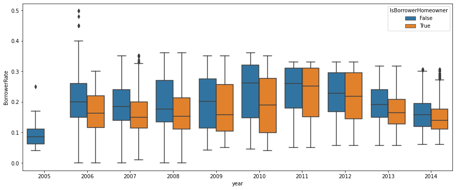

```python
# plots the boxplot to analyze homeowner's and non-homeowner's rate over years

g = sb.boxplot(data=Loan, x='year', y='BorrowerRate', hue='IsBorrowerHomeowner',order=order_date);
g.figure.set_figwidth(15)
g.figure.set_figheight(6)
```

### Insights

To exhibit the multivariate analysis, one particular scenario is taken i.e., analysing how the rate of interest changed over years for Homeowners vs Non-Homeowners and to depict this scenario, a boxplot is used because it can be easily analyzed with the advantage of having only two cases in the hue column. This boxplot shows that the borrower rate increased for some years in case of non homeowners, however it constantly decreased around 2010. As regards of homeowners, there wasn't much difference till 2009 but after 2009, the graph went up till 2011 and started falling off from then.

## Does Home Ownership lead to Higher Prosper Score ?

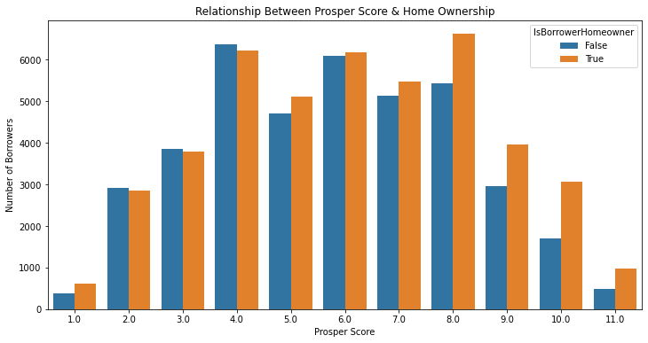

```python
fig = plt.figure(figsize=(12,6))
sb.countplot(hue='IsBorrowerHomeowner', x='ProsperScore', data=Loan)
plt.title('Relationship Between Prosper Score & Home Ownership')
plt.ylabel('Number of Borrowers')
plt.xlabel('Prosper Score')
plt.show()
```

## What is the relationship between Interest Rate, Yield and Estimated Loss ?

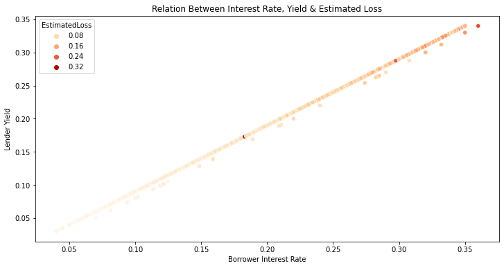

```python
fig = plt.figure(figsize=(12,6))
sb.scatterplot(x='BorrowerRate', y='LenderYield',
                hue='EstimatedLoss',y_jitter=0.9, data=Loan,
               palette='OrRd')
plt.title('Relation Between Interest Rate, Yield & Estimated Loss')
plt.xlabel('Borrower Interest Rate')
plt.ylabel('Lender Yield')
plt.show()
```